# BY-COVID - WP5 - Baseline Use Case: COVID-19 vaccine effectiveness assessment

Survival analysis

## Survival plot

We estimate the survival function using the Kaplan-Meier estimator and represent this function visually using a Kaplan-Meier curve, showing the probability of not getting infected by SARS-CoV-2 at a certain time after onset of follow-up. The survival function is estimated for the control and intervention group.

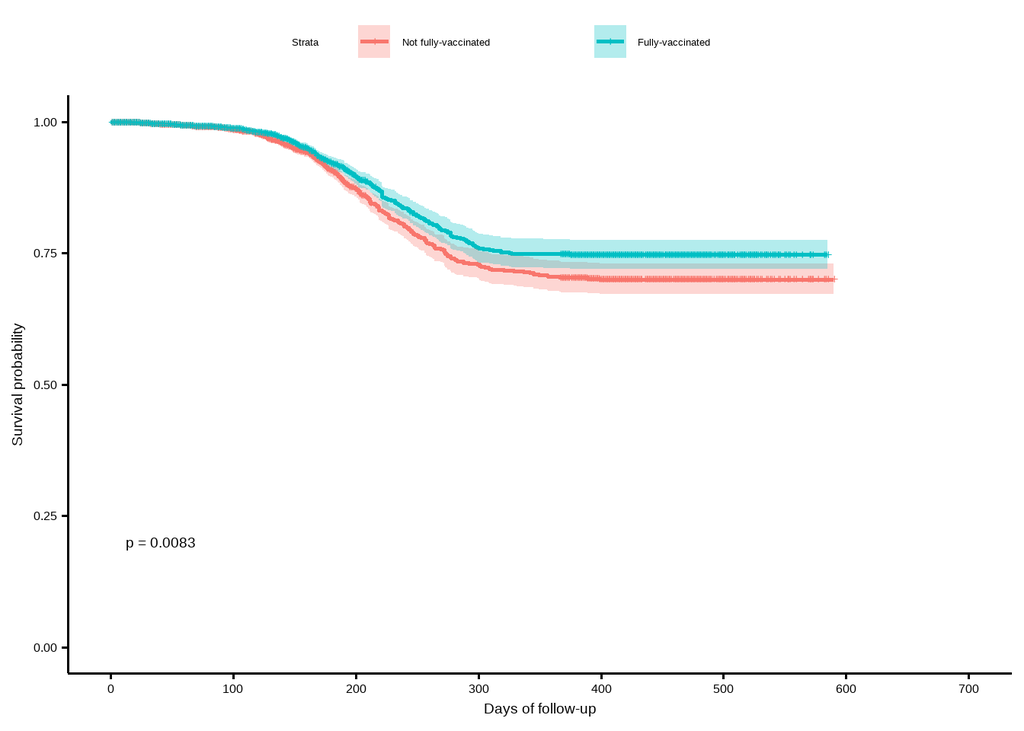

The cumulative incidence of the event (SARS-CoV-2 infection) was additionally plotted.

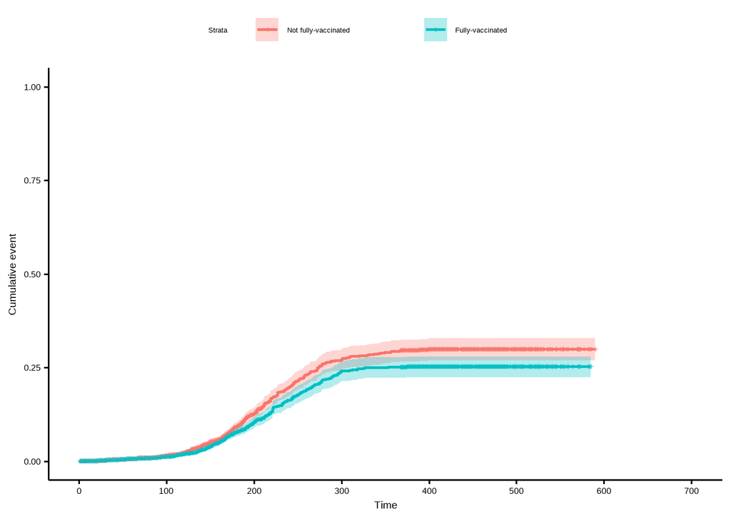

## Survival (time-to-event)

The probability of not getting infected by SARS-CoV-2 beyond a certain time after onset of follow-up (survival function, estimated using the Kaplan-Meier estimator) is reported for different periods.

| Strata | Time | Number at risk | Cumulative sum of number of events | Cumulative sum of number censored | Survival | Std. error | Cumulative hazard | Std. error cumulative hazard |
| --- | --- | --- | --- | --- | --- | --- | --- | --- |
| Not fully vaccinated | 0 | 8126 | 0 | 0 | 1.0000000 | 0.0000000000 | 0.0000000000 | 0.0000000000 |
| Not fully vaccinated | 100 | 2763 | 66 | 5318 | 0.9847823 | 0.0019551902 | 0.0153314345 | 0.0019849453 |
| Not fully vaccinated | 200 | 847 | 263 | 7036 | 0.8726674 | 0.0080760848 | 0.1360739611 | 0.0092447105 |
| Not fully vaccinated | 300 | 560 | 376 | 7191 | 0.7281129 | 0.0141570284 | 0.3168612254 | 0.0194130720 |
| Not fully vaccinated | 400 | 438 | 397 | 7296 | 0.7002962 | 0.0148648089 | 0.3557712590 | 0.0211948820 |
| Not fully vaccinated | 500 | 94 | 397 | 7642 | 0.7002962 | 0.0148648089 | 0.3557712590 | 0.0211948820 |
| Fully vaccinated | 0 | 8126 | 1 | 0 | 0.9998769 | 0.0001230542 | 0.0001230618 | 0.0001230618 |
| Fully vaccinated | 100 | 2766 | 56 | 5323 | 0.9875784 | 0.0017356656 | 0.0124969379 | 0.0017571346 |
| Fully vaccinated | 200 | 865 | 218 | 7065 | 0.8959358 | 0.0073702553 | 0.1098006111 | 0.0082190834 |
| Fully vaccinated | 300 | 580 | 324 | 7223 | 0.7587970 | 0.0137746103 | 0.2756498893 | 0.0181253151 |
| Fully vaccinated | 400 | 467 | 333 | 7332 | 0.7469473 | 0.0141146006 | 0.2913728635 | 0.0188680215 |
| Fully vaccinated | 500 | 98 | 333 | 7707 | 0.7469473 | 0.0141146006 | 0.2913728635 | 0.0188680215 |

## Median survival time

The median survival time is the time corresponding to a probability of not obtaining a SARS-CoV-2 infection probability of 0.5. (if NA, the probability of not obtaining a SARS-CoV-2 infection did not drop below 50%)

| **Characteristic** | **Median survival (95% CI)** |
| --- | --- |
| fully_vaccinated_bl |  |
| FALSE | — (—, —) |
| TRUE | — (—, —) |

## Cox regression and estimation of the average treatment effect

A Cox regression model was built to examine the relationship between the distribution of the probability of not obtaining a SARS-CoV-2 infection (survival distribution) and completing a primary vaccination schedule (covariate). The Cox proportional hazards regression model was fitted with ‘fully_vaccinated_bl’ as a covariate and accounts for clustering within individuals (as one individual can be re-sampled as control).

A hazard ratio (HR) is computed for the covariate ‘fully_vaccinated_bl’. A hazard can be interpreted as the instantaneous rate of SARS-CoV-2 infections in individuals that are at risk for obtaining an infection (Cox proportional hazards regression assumes stable proportional hazards over time). A HR < 1 indicates reduced hazard of SARS-CoV-2 infection when having completed a primary vaccination schedule whereas a HR > 1 indicates an increased hazard of SARS-CoV-2 infection.

|  | Parameter estimate | SE coefficient | Robust SE | P-value | Hazard Ratio (HR) (95% CI for HR) |
| --- | --- | --- | --- | --- | --- |
| fully_vaccinated_blTRUE | -0.196 | 0.074 | 0.095 | 0.039 | 0.822 (0.636, 1.008) |

The overall significance of the model is tested.

|  | Test statistic | Df | P-value |
| --- | --- | --- | --- |
| Likelihood ratio test | 6.976777 | 1 | 0.008257419 |
| Wald test | 4.270000 | 1 | 0.038863280 |
| Score (logrank) test | 6.970222 | 1 | 0.008287722 |
| Robust score test | 3.980840 | 1 | 0.046020612 |

Proportional hazards during the study period might be unlikely. As such, the RMST and RMTL ratios are additionally calculated, providing an alternative estimate for the the Average Treatment Effect (ATE), without requiring the proportional hazards assumption to be met.

| Arm | Measure | Estimate | SE | CI.lower | CI.upper |
| --- | --- | --- | --- | --- | --- |
| fully_vaccinated_bl==FALSE | RMST | 319.029 | 2.153 | 314.809 | 323.250 |
| fully_vaccinated_bl==TRUE | RMST | 326.172 | 2.014 | 322.224 | 330.119 |
| fully_vaccinated_bl==FALSE | RMTL | 45.971 | 2.153 | 41.750 | 50.191 |
| fully_vaccinated_bl==TRUE | RMTL | 38.828 | 2.014 | 34.881 | 42.776 |

| Measure | Estimate | CI.lower | CI.upper | p_value |
| --- | --- | --- | --- | --- |
| RMST (fully_vaccinated_bl==TRUE)-(fully_vaccinated_bl==FALSE) | 7.142 | 1.363 | 12.921 | 0.015 |
| RMST (fully_vaccinated_bl==TRUE)/(fully_vaccinated_bl==FALSE) | 1.022 | 1.004 | 1.041 | 0.016 |
| RMTL (fully_vaccinated_bl==TRUE)/(fully_vaccinated_bl==FALSE) | 0.845 | 0.737 | 0.969 | 0.016 |